# Final Project: Major League Baseball

Kyle Sorstokke

6/10/2020

## Plate Discipline and Offensive Success

In this analysis, I am seeking to understand the relationship between plate discipline (swinging at fewer pitches outside the strike zone) and offensive success, which I define using OPS+, a standardized measurement of on base percentage and slugging percentage around the league average of 100. Baseball coaches and players have historically argued over how aggressive an approach yields the most success, but experts seem to agree that selectivity is the most beneficial. With this in mind, my guiding question is: is plate discipline, defined by out of zone swing %, indicative of greater offensive success in terms of OPS+? I am also seeking to answer whether or not players can be grouped by plate discipline to better predict OPS+ since that approach is often used in practical baseball application. I will conduct my analysis using data from statcast, an automatic data collection tool created by MLB in 2015. The data is sourced from baseball savant, MLB’s official website for public statcast data.

```r
# Mutating statcast dataframe to include OPS+ and groupings of plate approach
statcast <- statcast %>%
  mutate(opsPlus = (on_base_percent / mean(on_base_percent) +
                      slg_percent / mean(slg_percent) - 1) * 100) %>%
  mutate(ozSwingGroup = cut(oz_swing_percent, c(10, 20, 30, 40, 50)))

# Creating train and test data sets (90% and 10%)
statTrain <- statcast[1:1592,]
statTest <- statcast[1593:nrow(statcast),]
```

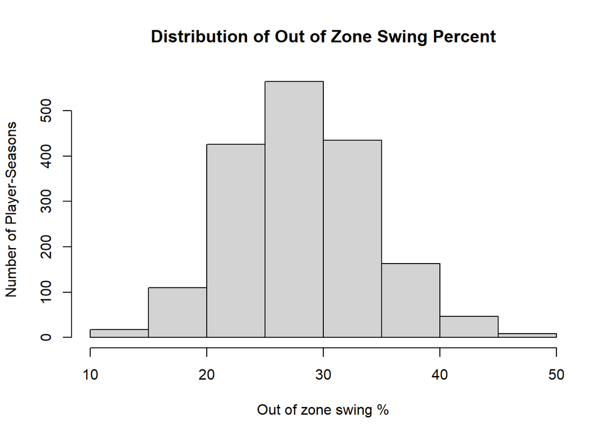

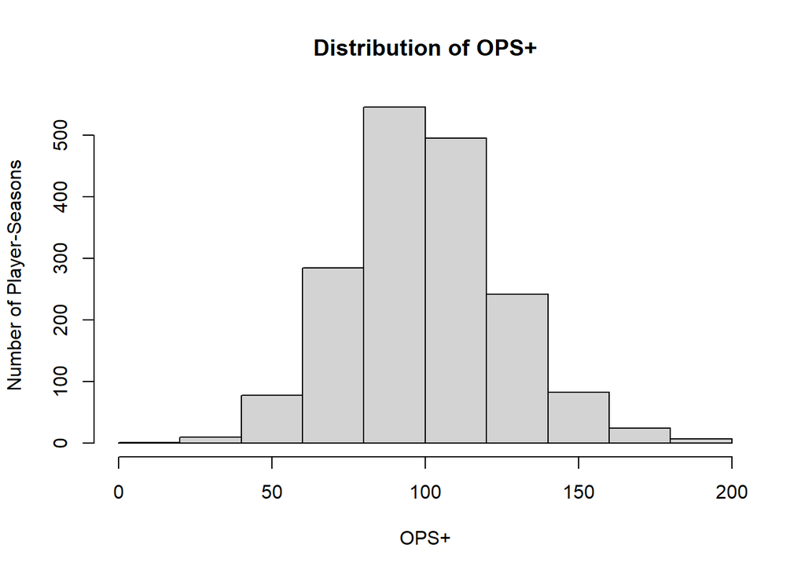

The histogram of OPS+ proves that the average player has an OPS+ of 100, with the majority of players clustered around the mean in a fairly normal distribution. This distribution is the point of OPS+; it takes OPS (on-base plus slugging), an unstandardized continuous metric for offensive output, and modifies it in relation to the league average.

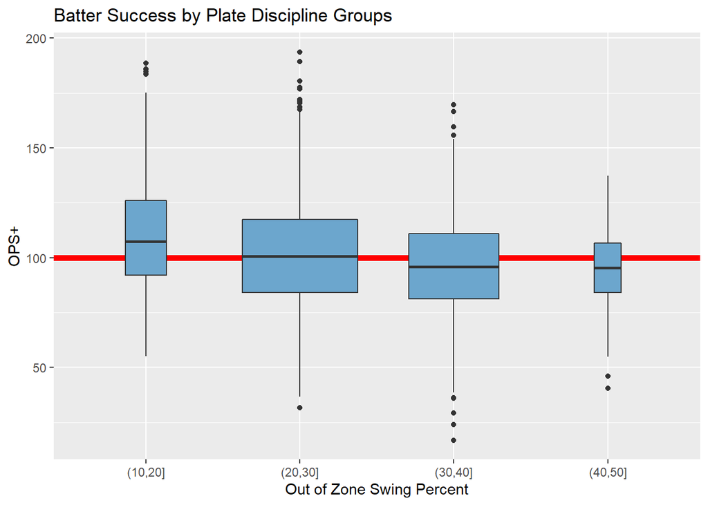

```r
opsMod <- aov(opsPlus ~ ozSwingGroup, data = statTrain)
summary(opsMod)
```

```
##                Df  Sum Sq Mean Sq F value   Pr(>F)
## ozSwingGroup    3   22911    7637   11.91 1.03e-07 ***
## Residuals    1588 1018439     641
## ---
## Signif. codes:  0 '***' 0.001 '**' 0.01 '*' 0.05 '.' 0.1 ' ' 1
```

```r
paste("RMSE:", rmse(statTest$opsPlus, predict(opsMod, statTest)))
```

```
## [1] "RMSE: 22.7936061065414"
```

I selected a one-way ANOVA test to understand how players can be grouped by out of zone swing % to analyze their resulting offensive success. For the outcome I selected OPS+ because it is one of the most respected metrics of individual offensive production, standardizing On-base plus slugging to a league average of 100, with a player at 150 producing 50% more offensive value. OPS+ typically only compares players from a single season, but I chose to use the entire statcast era (since data collection started in 2015) to increase the sample size and get a better understanding of overall trends. While out of zone swing % is a continuous variable, I grouped it as a factor because MLB analysts often seek to understand different approaches to hitting; one major factor in plate approach is discipline (swinging at good pitches in the strike zone and not pitches outside the strike zone). With this in mind, I created groups from out of zone swing % to create groups of players with similar plate discipline. The one-way ANOVA test allows me to determine if the groups do in fact have different sample means, which would prove that plate discipline does effect on offensive success.

In a one-way ANOVA test, the F value represents the ratio of variance between samples to variance within samples; the higher the value, the greater the relative difference in sample means. The common rejection level says that an F value < 1 means there is no significant difference between sample groups. My test yields an F value of 11.91 with a p-value of essentially 0; plate discipline, defined by out of zone swing rate, is indicative of greater success at the plate in terms of OPS+.

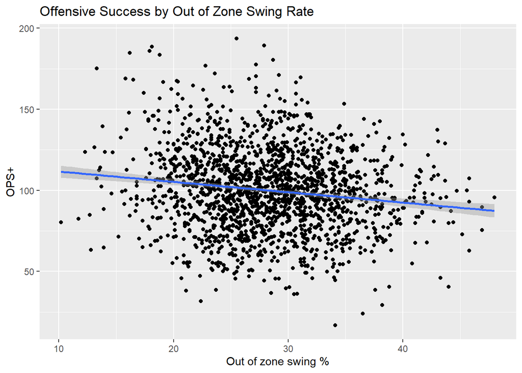

```r
linMod <- lm(opsPlus ~ oz_swing_percent, data = statTrain)
summary(linMod)
```

```
##
## Call:
## lm(formula = opsPlus ~ oz_swing_percent, data = statTrain)
##
## Residuals:
##     Min      1Q  Median      3Q     Max
## -78.990 -16.149  -0.301  15.731  92.299
##
## Coefficients:
##                  Estimate Std. Error t value Pr(>|t|)
## (Intercept)      118.0002     3.1202  37.818  < 2e-16 ***
## oz_swing_percent  -0.6499     0.1083  -6.001 2.43e-09 ***
## ---
## Signif. codes:  0 '***' 0.001 '**' 0.01 '*' 0.05 '.' 0.1 ' ' 1
##
## Residual standard error: 25.31 on 1590 degrees of freedom
## Multiple R-squared:  0.02214,    Adjusted R-squared:  0.02153
## F-statistic: 36.01 on 1 and 1590 DF,  p-value: 2.43e-09
```

```r
paste("RMSE:", rmse(statTest$opsPlus, predict(linMod, statTest)))
```

```
## [1] "RMSE: 22.9796231136793"
```